# Análisis de datos de metilación del TCGA-LUAD

- Mostrar todo el código
- Ocultar todo el código
- Ver el código fuente

Autor/a

Daniel González Cubides

## Objetivo del tutorial

Aprenderás a:

1. Descargar datos de microarreglos de metilación 450K del proyecto **TCGA-LUAD** (solo pacientes pareados)
2. Filtrar CpGs en regiones promotoras de genes candidatos
3. Comparar Tumor vs Normal pareado
4. Realizar pruebas estadísticas y generar visualizaciones

## 1. Preparación del entorno

## 1.1 Instalación de paquetes

**Código**

```r
# 1. Instalar el gestor de Bioconductor para instalar la libreria TCGAbiolinks, SummarizedExperiment

if (!requireNamespace("BiocManager", quietly = TRUE))
    install.packages("BiocManager")
BiocManager::install("BioinformaticsFMRP/TCGAbiolinksGUI.data")
BiocManager::install("BioinformaticsFMRP/TCGAbiolinks")
BiocManager::install("SummarizedExperiment")
BiocManager::install("sesame",ask = FALSE)
BiocManager::install("sesameData")
BiocManager::install("BiocParallel",ask = FALSE)

# 2. Instalar/cargar el resto de paquetes CRAN normales
if (!require("pacman", quietly = TRUE)) install.packages("pacman")
pacman::p_load(dplyr, tidyr, tidyverse, ggplot2, pheatmap, openxlsx, writexl, here, patchwork, factoextra, FactoMineR)
```

## 1.2 Carga de paquetes

**Código**

```r
# 1. Cargar los paquetes de Bioconductor que necesitamos
suppressPackageStartupMessages({
  library(TCGAbiolinks)
  library(SummarizedExperiment)
  library(sesame)
  library(sesameData)
})

# 2. Cargar el resto de paquetes CRAN normales
if (!require("pacman", quietly = TRUE)) install.packages("pacman")

suppressPackageStartupMessages(
  pacman::p_load_gh(
    "dplyr", "tidyr", "tidyverse", "ggplot2", "pheatmap",
    "openxlsx", "writexl", "here", "patchwork",
    "factoextra", "FactoMineR",
    quietly = TRUE
  )
)

# 3. Verificación de la carga de los paquetes
cat("¡Todo instalado y cargado correctamente! ✅\n")
```

```
¡Todo instalado y cargado correctamente! ✅
```

**Código**

```r
cat("Versión de R:", R.version.string, "\n")
```

```
Versión de R: R version 4.5.1 (2025-06-13 ucrt)
```

**Código**

```r
cat("TCGAbiolinks version:", as.character(packageVersion("TCGAbiolinks")), "\n")
```

```
TCGAbiolinks version: 2.36.0
```

**Código**

```r
cat("SummarizedExperiment version:", as.character(packageVersion("SummarizedExperiment")), "\n")
```

```
SummarizedExperiment version: 1.38.1
```

**Código**

```r
cat("sesame version:", as.character(packageVersion("sesame")), "\n")
```

```
sesame version: 1.26.0
```

## 2. Consulta de los datos disponibles del proyecto

Hacer los análisis en R nos da la posibilidad de filtrar los sujetos según múltiples variables clínicas y demográficas. En este caso se filtrará para comparar muestras tumorales con tejido normal adyacente del mismo paciente, esto disminuye la cantidad de datos usables, pero asegura que las diferencias observadas se deben principalmente al estado tumoral y no a factores genéticos o ambientales específicos de cada individuo, mejorando la precisión y relevancia biológica del análisis. La codificación del TCGA se encuentra [aquí](https://gdc.cancer.gov/resources-tcga-users/tcga-code-tables).

**Código**

```r
## Consulta de metadatos TCGA-LUAD:
# Aquí construimos la consulta para obtener metadatos de muestras tumorales y normales.
query <- GDCquery(
  project = "TCGA-LUAD",
  data.category = "DNA Methylation",
  platform = "Illumina Human Methylation 450",
  data.type = "Methylation Beta Value",
  sample.type = c("Primary Tumor", "Solid Tissue Normal")
)

# Extraemos la tabla de resultados y generamos identificadores de paciente y tipo de muestra.
meta <- query$results[[1]]
meta$patient <- substr(meta$cases, 1, 12)
meta$type    <- substr(meta$cases, 14, 15)

## Selección de pacientes pareados (tumor vs normal)
# Buscamos pacientes con ambos tipos: 01 (Primary Tumor) y 11 (Solid Tissue Normal)
pacientes_pareados <- meta %>%
  group_by(patient) %>%
  filter(all(c("01", "11") %in% type)) %>%
  pull(patient) %>% unique()

cat("Pacientes con muestras pareadas:", length(pacientes_pareados), "\n")
```

## 2.1 Descarga de datos (opcional)

> ⏰ Esta celda tarda 10-20 minutos y descarga ~2 GB. Después ya no la vuelvas a ejecutar.

**Código**

```r
# Descarga solo esos pacientes
# Con el vector de barcodes descargamos los ficheros y preparamos un SummarizedExperiment.
query_pareados <- GDCquery(
  project = "TCGA-LUAD",
  data.category = "DNA Methylation",
  platform = "Illumina Human Methylation 450",
  data.type = "Methylation Beta Value",
  barcode = meta$cases[meta$patient %in% pacientes_pareados]
)

# Descargar (puede tardar) y preparar en memoria. Ajusta 'directory' si usas otra carpeta.
GDCdownload(query_pareados, directory = here("data"))
luad_data <- GDCprepare(query_pareados, directory = here("data"))

# Guardamos un RDS para poder reanudar el análisis sin volver a descargar.
saveRDS(luad_data, here("data", "LUAD_pareados_raw.rds"))
```

## 3. Cargar los datos

**Código**

```r
## CHECKPOINT: Si ya descargaste y guardaste los datos, puedes iniciar aquí cargando el RDS.
luad_data <- readRDS(here("data", "LUAD_pareados_raw.rds"))
luad_data
```

```
class: RangedSummarizedExperiment
dim: 485577 67
metadata(1): data_release
assays(1): ''
rownames(485577): cg13869341 cg14008030 ... cg11478607 cg08417382
rowData names(52): address_A address_B ... MASK_extBase MASK_general
colnames(67): TCGA-44-2665-01A-01D-A276-05 TCGA-44-2665-01B-06D-A276-05
  ... TCGA-50-6594-11A-01D-1756-05 TCGA-50-6594-01A-11D-1756-05
colData names(91): barcode patient ... paper_Ploidy.ABSOLUTE.calls
  paper_Purity.ABSOLUTE.calls
```

## 4. Descarga de anotación de las sondas del microarreglo

**Código**

```r
# Esto descarga automáticamente la anotación 450K la primera vez (~50 MB) y la guarda en caché para siempre
sesameDataCache(c("HM450.probeInfo","genomeInfo.hg38","HM450.address"))
promoter_probes <- sesameData_getProbesByGene(NULL, "HM450", promoter = TRUE)
cat("Número de CpGs en promotor:", nrow(promoter_probes), "\n")
```

```
Número de CpGs en promotor:
```

## 5. Genes de interés y filtrado de promotores

**Código**

```r
# Cambia o amplía esta lista según tus genes candidatos
genes_interes <- c("CDKN2A", "CDH13", "MIR137", "MGMT", "DAPK1",
           "RARB", "RASSF1", "AHRR", "GSTP1", "CASC8")

# Obtener sondas de promotor para cada gen
sondas_promotor <- lapply(genes_interes, function(gen) {
  sesameData_getProbesByGene(gen, "HM450", promoter = TRUE)
})
names(sondas_promotor) <- genes_interes

#Checkpoint en caso de falla de sesame
# saveRDS(sondas_promotor, here("data", "sondas_promotor.rds"))
# También se puede cargar desde aquí para facilitar el proceso
# sondas_promotor <- readRDS(here("data", "sondas_promotor.rds"))

# Ver cuántas sondas hay por gen
sapply(sondas_promotor, length)
```

```
CDKN2A  CDH13 MIR137   MGMT  DAPK1   RARB RASSF1   AHRR  GSTP1  CASC8
     4      5      8     11     11      5     29     21     10      3
```

**Código**

```r
rownames(as.data.frame(sondas_promotor$CDKN2A))
```

```
[1] "cg04026675" "cg13601799" "cg03079681" "cg14069088"
```

**Código**

```r
# Filtrado de la matriz para quedarnos solo con las sondas de interés
sondas_df <- bind_rows(lapply(names(sondas_promotor), function(gen) {
  df <- as.data.frame(sondas_promotor[[gen]])
  df$gene <- gen
  df$probe <- rownames(df)
  return(df)
}), .id = NULL) %>%
  distinct(probe, .keep_all = TRUE)   # por si alguna sonda está en dos promotores

# Obtenemos la matriz de valores betas y la anotación de las sondas del microarreglo 450k
beta <- assay(luad_data)                               # CpGs x muestras
beta_promotores <- beta[sondas_df$probe, ]             # CpGs en promotor x muestras
rowData <- sondas_df$gene

cat("Total de CpGs en promotores de genes de interés:", nrow(beta_promotores), "\n")
```

```
Total de CpGs en promotores de genes de interés: 107
```

## 6. Alineación de muestras pareadas (una columna por paciente y tipo)

**Código**

```r
alinear_muestras <- function(mat) {
  col_info <- colnames(mat) # Obtiene los ids de las muestras
  paciente <- substr(col_info, 1, 12) # Extrae el código del paciente (TCGA-XX-XXXX)
# Extrae el tipo de muestra: "01" = tumor primario, "11" = tejido normal, etc.
  tipo     <- ifelse(substr(col_info, 14, 15) == "01", "Tumor", "Normal")
  id       <- paste(paciente, tipo, sep = "_") # Une el código del paciente y el tipo de muestra

# -------------------------------------------------
# Promediar duplicados (por si acaso hubiera más de una muestra del mismo tipo para un paciente)
# -------------------------------------------------
  mat_t    <- t(mat) # Transpone la matriz para que las muestras queden como filas
  mat_aggr <- aggregate(mat_t, by = list(id), FUN = mean) # Promedia posibles duplicados
  rownames(mat_aggr) <- mat_aggr$Group.1 # Pone como nombres de fila el identificador paciente_tipo
  mat_aggr <- mat_aggr[, -1] %>% t() # Elimina la columna auxiliar "Group.1" que creó aggregate y retorna al orden original

# -------------------------------------------------
# Ordenar las columnas: primero todas las muestras Normal, luego todas las Tumor
# -------------------------------------------------
  normal <- grep("_Normal$", colnames(mat_aggr)) # Índice de muestras con sufijo "_Normal"
  tumor  <- grep("_Tumor$",  colnames(mat_aggr)) # Índice de muestras con sufijo "_Tumor"
  mat_aggr[, c(sort(normal), sort(tumor))] # Reordena las columnas por orden alfabético y Normal → Tumor
}

luad_alineado <- alinear_muestras(beta_promotores)

row_sums <- rowSums(luad_alineado, na.rm = TRUE)# Calcula la suma de valores beta por cada fila (es decir, por cada CpG/probe)
luad_alineado<-luad_alineado[!row_sums == 0 & !is.na(row_sums),] # Filtra la matriz: elimina aquellas sondas (filas) cuya suma de betas sea exactamente 0

luad_alineado[1:6, c(1:4,30:33)]
```

```
           TCGA-05-5420_Normal TCGA-38-4631_Normal TCGA-38-4632_Normal
cg04026675          0.13689238          0.12768721          0.10921884
cg13601799          0.01880825          0.02406962          0.01801907
cg03079681          0.03812180          0.03803923          0.03331815
cg14069088          0.67074051          0.72697647          0.37655482
cg01880569          0.62099725          0.73976529          0.63633959
cg01301138          0.11489441          0.13632058          0.11115322
           TCGA-44-2656_Normal TCGA-05-5420_Tumor TCGA-38-4631_Tumor
cg04026675          0.15644828         0.09387257         0.20675555
cg13601799          0.02770444         0.03088025         0.02481353
cg03079681          0.04419395         0.06044186         0.03940715
cg14069088          0.44168010         0.44467695         0.15607633
cg01880569          0.72224243         0.77499490         0.80015525
cg01301138          0.11142424         0.16081557         0.13114383
           TCGA-38-4632_Tumor TCGA-44-2656_Tumor
cg04026675         0.25519613         0.43154714
cg13601799         0.02431359         0.37581740
cg03079681         0.04518259         0.04961183
cg14069088         0.66316443         0.58131778
cg01880569         0.77624520         0.84372839
cg01301138         0.30582718         0.32222006
```

## 7. Formato largo para realizar análisis y gráficos

**Código**

```r
# 1. Convertir la matriz alineada a formato largo (tidy)
luad_long <- luad_alineado %>%
  as.data.frame() %>%
  rownames_to_column("probe") %>%
  pivot_longer(-probe, names_to = "sample", values_to = "beta") %>%
  separate(sample, into = c("patient", "group"), sep = "_") %>%
  mutate(group = factor(group, levels = c("Normal", "Tumor")))

# 2. Añadir el nombre del gen correspondiente a cada probe con sondas_df (contiene probe → gene)
luad_long <- luad_long %>%
  left_join(
    sondas_df %>% select(probe, gene),   # Solo necesitamos probe y gene
    by = "probe"
  )

# 3. Reordenar columnas para que quede más limpio
luad_long <- luad_long %>%
  select(probe, gene, patient, group, beta)

# 5. Verificar que todo salió bien
cat("Dimensiones de luad_long:", dim(luad_long), "\n")
```

```
Dimensiones de luad_long: 5742 5
```

**Código**

```r
cat("Genes estudiados:", paste(unique(luad_long$gene), collapse = ", "), "\n")
```

```
Genes estudiados: CDKN2A, CDH13, MIR137, MGMT, DAPK1, RARB, RASSF1, AHRR, GSTP1, CASC8
```

**Código**

```r
head(luad_long)
```

```
# A tibble: 6 × 5
  probe      gene   patient      group   beta
  <chr>      <chr>  <chr>        <fct>  <dbl>
1 cg04026675 CDKN2A TCGA-05-5420 Normal 0.137
2 cg04026675 CDKN2A TCGA-38-4631 Normal 0.128
3 cg04026675 CDKN2A TCGA-38-4632 Normal 0.109
4 cg04026675 CDKN2A TCGA-44-2656 Normal 0.156
5 cg04026675 CDKN2A TCGA-44-2665 Normal 0.106
6 cg04026675 CDKN2A TCGA-44-2668 Normal 0.187
```

# 8. Visualizaciones preliminares:

## 8.1 Distribución global (densidad)

**Código**

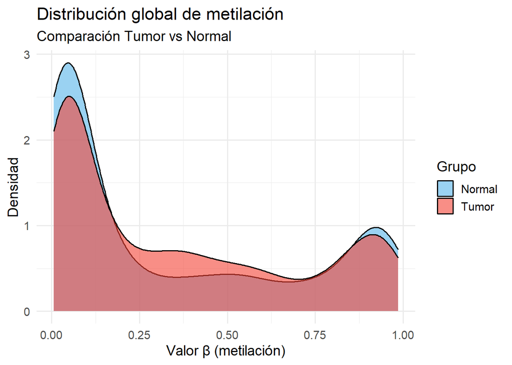

```r
# Densidad de valores beta por grupo
ggplot(luad_long, aes(x = beta, fill = group)) +
  geom_density(alpha = 0.6) +
  scale_fill_manual(values = c("Normal" = "#56B4E9", "Tumor" = "#F44336")) +
  labs(title = "Distribución global de metilación",
       subtitle = "Comparación Tumor vs Normal",
       x = "Valor β (metilación)",
       y = "Densidad",
       fill = "Grupo") +
  theme_minimal(base_size = 14)
```

## 8.2 Boxplots

**Código**

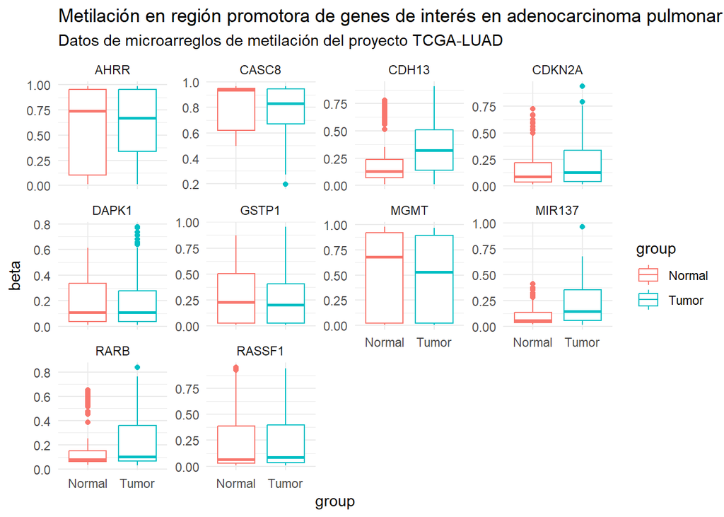

```r
ggplot(luad_long, aes(x = group, y = beta, color = group)) +
  geom_boxplot() +
  facet_wrap(~ gene, scales = "free_y") +
  theme_minimal() +
  labs(title = "Metilación en región promotora de genes de interés en adenocarcinoma pulmonar",
       subtitle = "Datos de microarreglos de metilación del proyecto TCGA-LUAD")
```

## 9. Análisis estadístico: Wilcoxon + FDR por cada sitio CG

**Código**

```r
resultados <- luad_long %>%
  group_by(probe, gene) %>%
  summarise(p_val = wilcox.test(beta ~ group)$p.value,
            .groups = "drop") %>%
  group_by(gene) %>%
  mutate(p_adj_gen = p.adjust(p_val, method = "fdr")) %>%
  ungroup() %>%
  arrange(p_adj_gen)

# Filtrar CpGs significativos
cpgs_sig <- resultados %>% filter(p_adj_gen < 0.05)

cat("CpGs significativos (FDR < 0.05 por gen):", nrow(cpgs_sig), "\n")
```

```
CpGs significativos (FDR < 0.05 por gen): 42
```

**Código**

```r
# Ver los top resultados
head(cpgs_sig)
```

```
# A tibble: 6 × 4
  probe      gene      p_val p_adj_gen
  <chr>      <chr>     <dbl>     <dbl>
1 cg05244766 GSTP1  1.72e-11  1.20e-10
2 cg04743654 RASSF1 6.35e- 9  1.84e- 7
3 cg08747377 CDH13  5.17e- 8  2.58e- 7
4 cg25866895 GSTP1  1.99e- 7  6.97e- 7
5 cg25372296 MIR137 1.15e- 7  9.19e- 7
6 cg05374412 CDH13  4.63e- 7  1.16e- 6
```

## 9.1 Análisis estadístico: Wilcoxon + FDR por cada gen

**Código**

```r
# Agregar a nivel de gen (promediando las probes)
resultados_gen <- luad_long %>%
  group_by(gene, patient, group) %>%
  summarise(beta_promedio = mean(beta, na.rm = TRUE),
            n_probes = n_distinct(probe),  # Calcular aquí el número de probes
            .groups = "drop") %>%
  group_by(gene) %>%
  summarise(
    p_val = wilcox.test(beta_promedio ~ group)$p.value,
    mean_normal = mean(beta_promedio[group == "Normal"], na.rm = TRUE),
    mean_tumor = mean(beta_promedio[group == "Tumor"], na.rm = TRUE),
    delta_beta = mean_tumor - mean_normal,
    n_probes = first(n_probes),  # Tomar el valor (es el mismo para todos)
    .groups = "drop"
  ) %>%
  mutate(p_adj = p.adjust(p_val, method = "fdr")) %>%
  arrange(p_adj)%>%
  select(gene, n_probes, mean_normal, mean_tumor, delta_beta, p_val, p_adj)

# Genes significativos
genes_sig <- resultados_gen %>% filter(p_adj < 0.05)
cat("Genes significativos (FDR < 0.05):", nrow(genes_sig), "\n")
```

```
Genes significativos (FDR < 0.05): 4
```

**Código**

```r
head(genes_sig)
```

```
# A tibble: 4 × 7
  gene   n_probes mean_normal mean_tumor delta_beta    p_val    p_adj
  <chr>     <int>       <dbl>      <dbl>      <dbl>    <dbl>    <dbl>
1 MIR137        8      0.0964      0.211     0.115  5.07e-11 5.07e-10
2 CDH13         5      0.216       0.352     0.136  3.39e- 7 1.70e- 6
3 MGMT         10      0.512       0.490    -0.0223 1.39e- 6 4.62e- 6
4 GSTP1         7      0.274       0.235    -0.0388 4.21e- 4 1.05e- 3
```

## 9.2 Exportación del análisis estadístico

**Código**

```r
# Crear lista con ambas hojas
lista_resultados <- list(
  "Sitios CpG significativos" = cpgs_sig,
  "Genes dif. metilados" = genes_sig
)

# Exportar a Excel
write_xlsx(lista_resultados, here("results", "Resultados_análisis_estadístico_LUAD.xlsx"))

cat("Archivo exportado: resultados_metilacion.xlsx\n")
```

```
Archivo exportado: resultados_metilacion.xlsx
```

**Código**

```r
cat("- Hoja 1: Sitios CpG significativos (", nrow(cpgs_sig), " filas)\n")
```

```
- Hoja 1: Sitios CpG significativos ( 42  filas)
```

**Código**

```r
cat("- Hoja 2: Genes diferencialmente metilados (", nrow(genes_sig), " filas)\n")
```

```
- Hoja 2: Genes diferencialmente metilados ( 4  filas)
```

# 10. Visualizaciones finales:

## 10.1 Histograma de valores p

**Código**

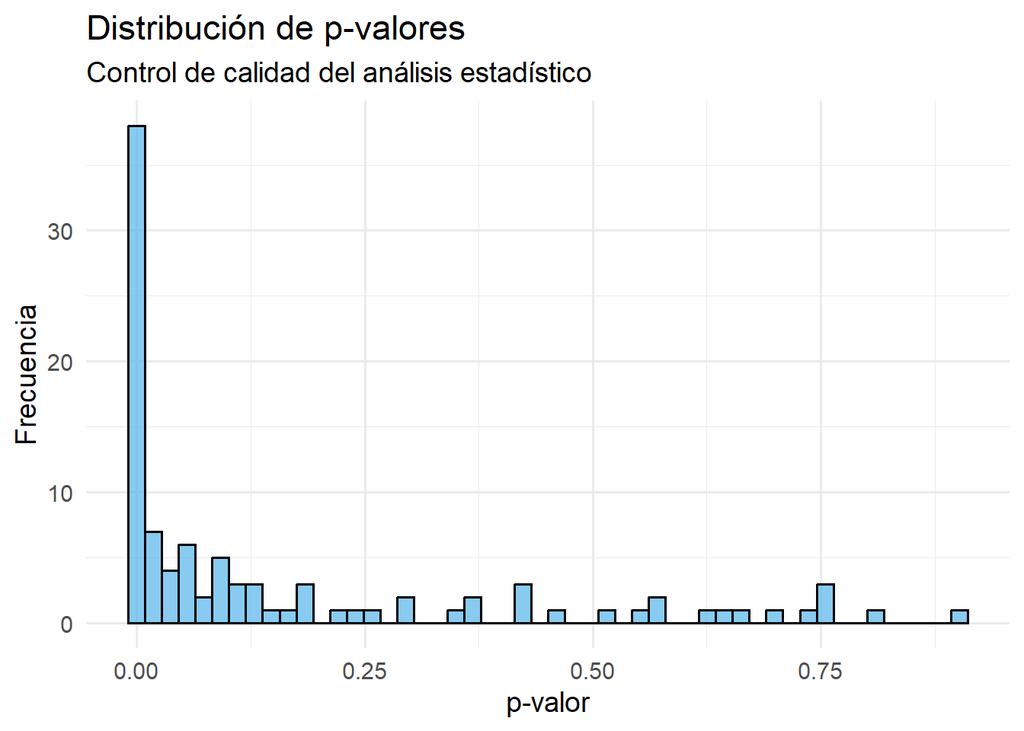

```r
# Distribución de p-valores (QC)
ggplot(resultados, aes(x = p_val)) +
  geom_histogram(bins = 50, fill = "#56B4E9", color = "black", alpha = 0.7) +
  labs(title = "Distribución de p-valores",
       subtitle = "Control de calidad del análisis estadístico",
       x = "p-valor",
       y = "Frecuencia") +
  theme_minimal(base_size = 14)
```

## 10.2 Barplot de la cantidad de CpGs significativos por gen

**Código**

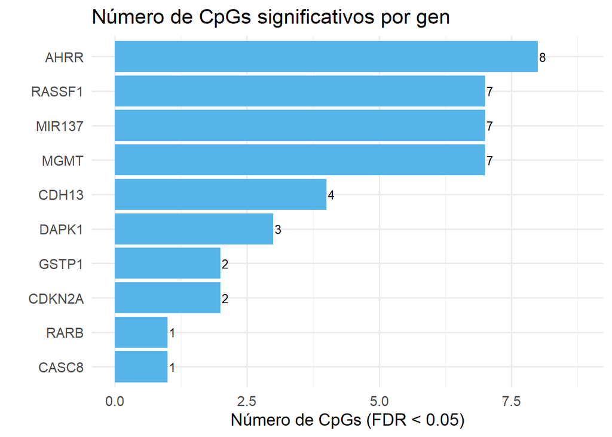

```r
# Conteo de CpGs significativos por gen
cpgs_sig %>%
  count(gene) %>%
  arrange(desc(n)) %>%
  head(20) %>%
  mutate(gene = reorder(gene, n)) %>%
  ggplot(aes(x = n, y = gene)) +
  geom_col(fill = "#56B4E9") +
  geom_text(aes(label = n), hjust = -0.2, size = 3.5) +
  labs(title = "Número de CpGs significativos por gen",
       x = "Número de CpGs (FDR < 0.05)",
       y = "") +
  theme_minimal(base_size = 14) +
  xlim(0, max(cpgs_sig %>% count(gene) %>% pull(n)) * 1.1)
```

**Código**

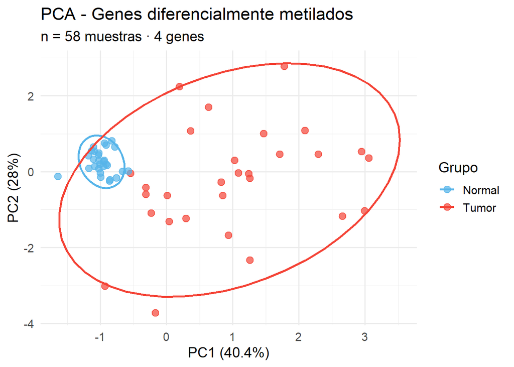

```r
# PCA a nivel de gen (más robusto, menos NAs)
pca_data <- luad_long %>%
  filter(gene %in% genes_sig$gene) %>%
  group_by(gene, patient, group) %>%
  summarise(beta_mean = mean(beta, na.rm = TRUE), .groups = "drop") %>%
  mutate(sample_id = paste0(patient, "_", group)) %>%
  select(gene, sample_id, beta_mean, group) %>%
  pivot_wider(names_from = gene, values_from = beta_mean)

# Limpiar NAs
pca_data_clean <- pca_data %>% drop_na()

# Matriz para PCA
pca_matrix <- pca_data_clean %>% select(-sample_id, -group) %>% as.matrix()

# Ejecutar PCA
pca_res <- prcomp(pca_matrix, scale. = TRUE, center = TRUE)

# Crear dataframe
pca_df <- data.frame(
  PC1 = pca_res$x[, 1],
  PC2 = pca_res$x[, 2],
  grupo = pca_data_clean$group,
  sample = pca_data_clean$sample_id
)

# Varianza explicada
var_exp <- round(100 * summary(pca_res)$importance[2, 1:2], 1)

# Visualizar
ggplot(pca_df, aes(x = PC1, y = PC2, color = grupo)) +
  geom_point(size = 3, alpha = 0.7) +
  stat_ellipse(level = 0.95, linewidth = 1) +
  scale_color_manual(values = c("Normal" = "#56B4E9", "Tumor" = "#F44336")) +
  labs(
    title = "PCA - Genes diferencialmente metilados",
    subtitle = paste("n =", nrow(pca_df), "muestras ·", ncol(pca_matrix), "genes"),
    x = paste0("PC1 (", var_exp[1], "%)"),
    y = paste0("PC2 (", var_exp[2], "%)"),
    color = "Grupo"
  ) +
  theme_minimal(base_size = 14)
```

## 10.4 Barplot de genes con cambios significativos

**Código**

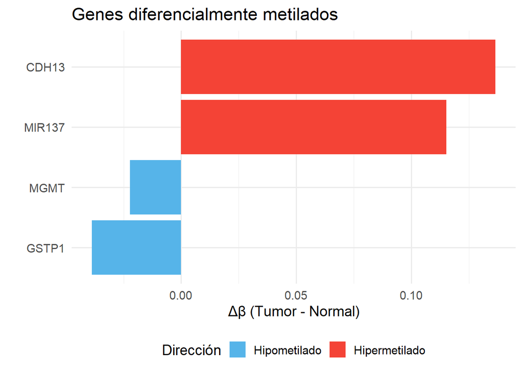

```r
# Top genes por delta beta
genes_sig %>%
  arrange(desc(abs(delta_beta))) %>%
  mutate(gene = reorder(gene, delta_beta)) %>%
  ggplot(aes(x = delta_beta, y = gene, fill = delta_beta > 0)) +
  geom_col() +
  scale_fill_manual(values = c("TRUE" = "#F44336", "FALSE" = "#56B4E9"),
                    labels = c("Hipometilado", "Hipermetilado")) +
  labs(title = "Genes diferencialmente metilados",
       x = "Δβ (Tumor - Normal)",
       y = "",
       fill = "Dirección") +
  theme_minimal(base_size = 14) +
  theme(legend.position = "bottom")
```

## 10.5 Heatmap de CpGs significativos

**Código**

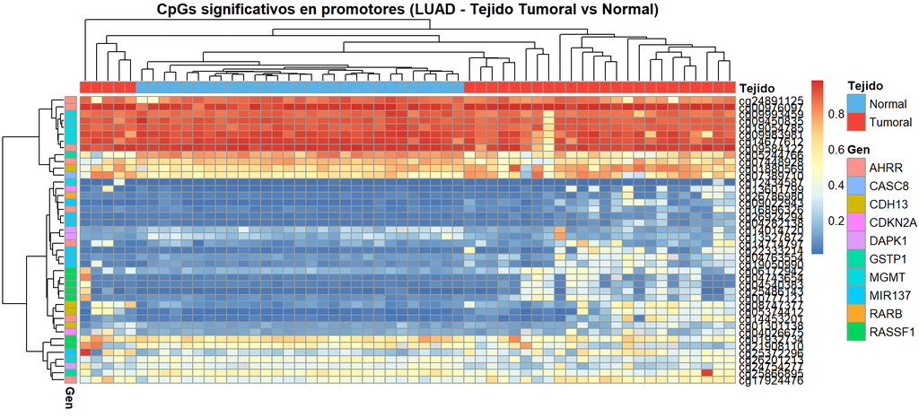

```r
if (nrow(cpgs_sig) > 0) {
  mat_sig <- luad_alineado[cpgs_sig$probe, ]

  # Anotación de filas
  anno_row <- data.frame(
    Gen = cpgs_sig$gene[match(rownames(mat_sig), cpgs_sig$probe)],
    row.names = rownames(mat_sig)
  )

  # Anotación de columnas
  anno_col <- data.frame(
    Tejido = ifelse(grepl("_Normal$", colnames(mat_sig)), "Normal", "Tumoral"),
    row.names = colnames(mat_sig)
  )

  # Colores personalizados
  anno_colors <- list(
    Tejido = c(Normal = "#56B4E9", Tumoral = "#F44336")
  )

  pheatmap(mat_sig,
           cluster_rows = TRUE,
           cluster_cols = TRUE,

           show_rownames = ifelse(nrow(mat_sig) < 50, TRUE, FALSE),
           show_colnames = FALSE,
           annotation_row = anno_row,
           annotation_col = anno_col,
           annotation_colors = anno_colors,
           main = "CpGs significativos en promotores (LUAD - Tejido Tumoral vs Normal)",
           fontsize = 10)
}
```

## 10.6 Heatmap de genes significativos

**Código**

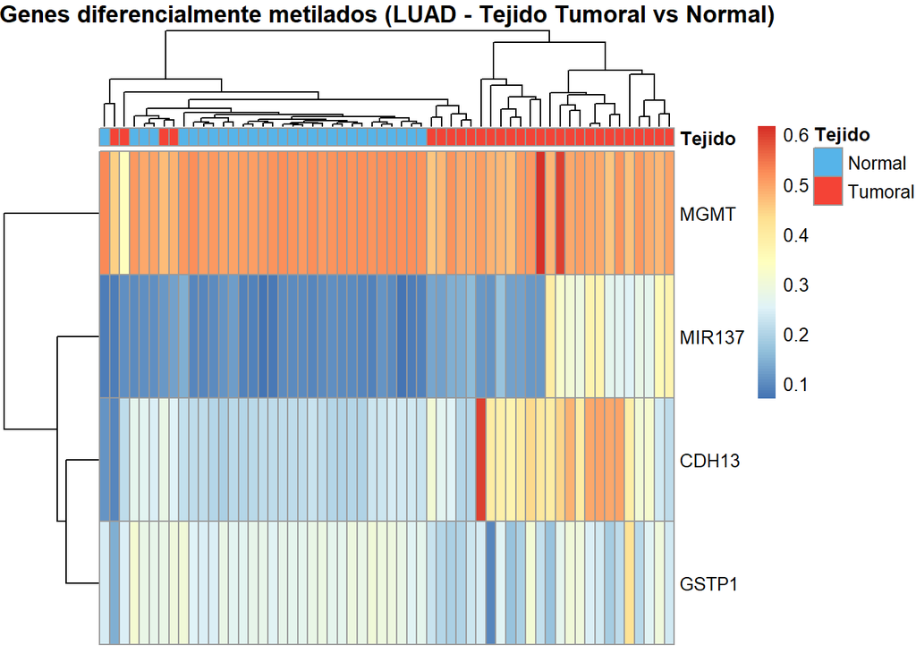

```r
if (nrow(genes_sig) > 0) {
  # Crear matriz agregada por gen
  mat_gen <- luad_long %>%
    filter(gene %in% genes_sig$gene) %>%
    group_by(gene, patient, group) %>%
    summarise(beta_promedio = mean(beta, na.rm = TRUE), .groups = "drop") %>%
    mutate(sample_id = paste0(patient, "_", group)) %>%
    select(gene, sample_id, beta_promedio) %>%
    pivot_wider(names_from = sample_id, values_from = beta_promedio) %>%
    column_to_rownames("gene") %>%
    as.matrix()

  # Anotación de columnas
  anno_col <- data.frame(
    Tejido = ifelse(grepl("_Normal$", colnames(mat_gen)), "Normal", "Tumoral"),
    row.names = colnames(mat_gen)
  )

  # Colores personalizados
  anno_colors <- list(
    Tejido = c(Normal = "#56B4E9", Tumoral = "#F44336")
  )

  pheatmap(mat_gen,
           cluster_rows = TRUE,
           cluster_cols = TRUE,
           show_rownames = TRUE,  # Mostrar nombres de genes
           show_colnames = FALSE,
           annotation_col = anno_col,
           annotation_colors = anno_colors,
           main = "Genes diferencialmente metilados (LUAD - Tejido Tumoral vs Normal)",
           fontsize = 10)
}
```

## 10.7 Violin + boxplots por gen (solo genes significativos)

**Código**

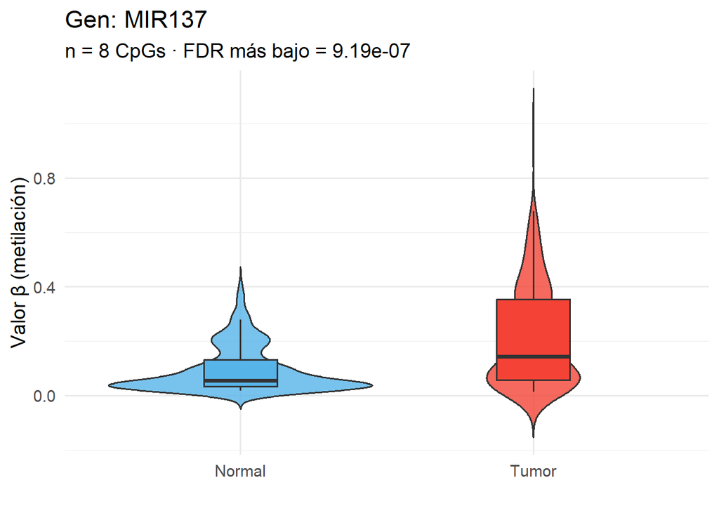

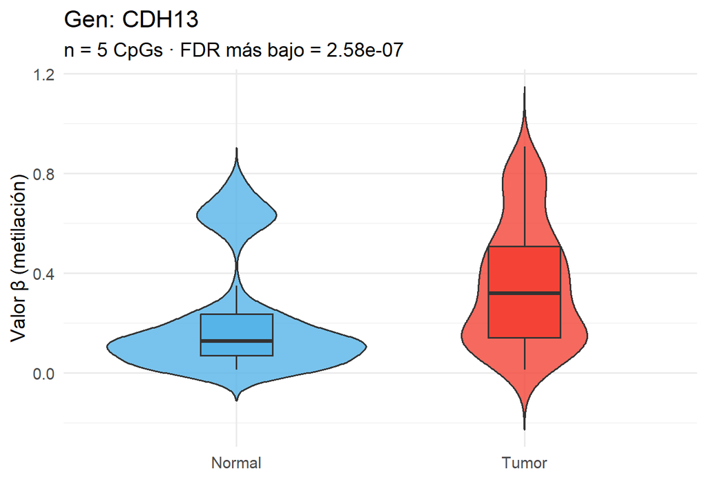

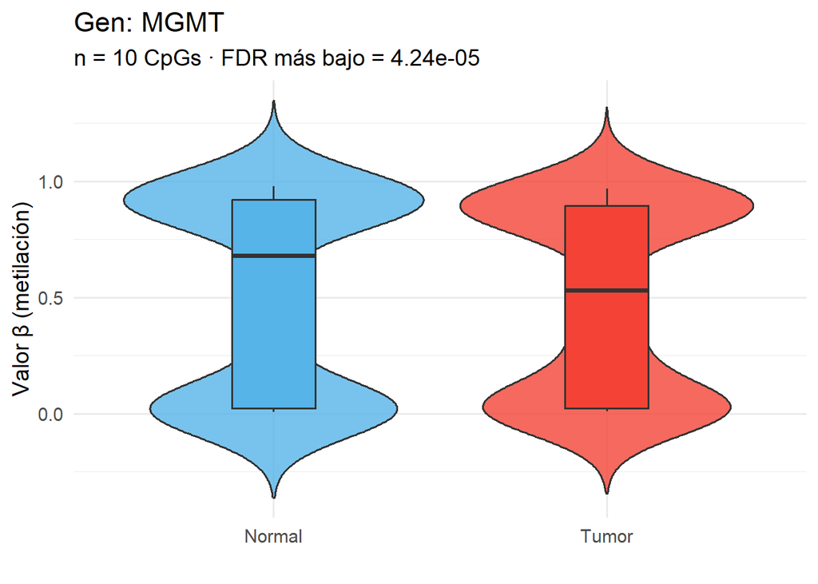

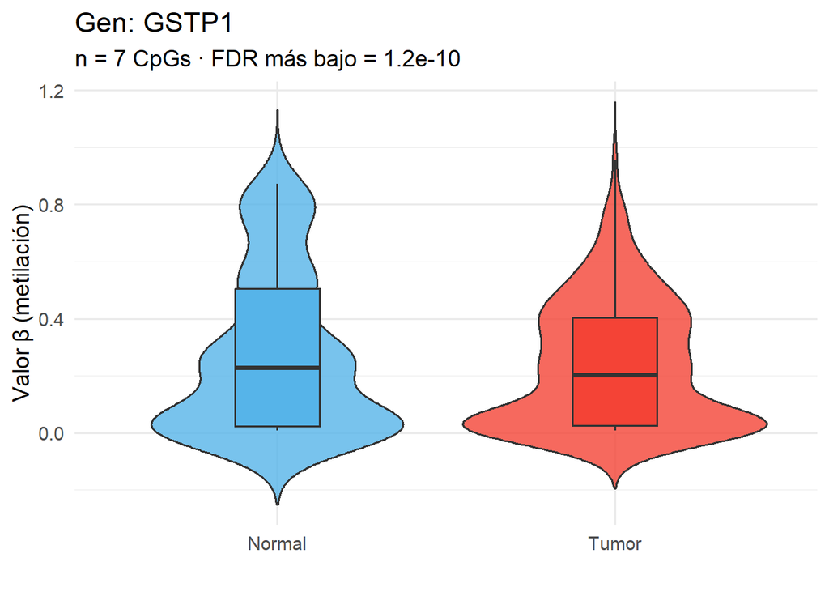

```r
for (g in genes_sig$gene) {
  dat <- luad_long %>% filter(gene == g)

  p <- ggplot(dat, aes(x = group, y = beta, fill = group)) +
    geom_violin(trim = FALSE, alpha = 0.8) +
    geom_boxplot(width = 0.25, outlier.alpha = 0) +
    scale_fill_manual(values = c("Normal" = "#56B4E9", "Tumor" = "#F44336")) +
    labs(title = paste("Gen:", g),
         subtitle = paste("n =", length(unique(dat$probe)), "CpGs · FDR más bajo =",
                          format(min(cpgs_sig$p_adj_gen[cpgs_sig$gene == g]), scientific = TRUE, digits = 3)),
         y = "Valor β (metilación)",
         x = "") +
    theme_minimal(base_size = 14) +
    theme(legend.position = "none")

  print(p)
}
```

## 10.8 Violin + boxplots por gen **con cada observación resaltada** (solo genes significativos)

**Código**

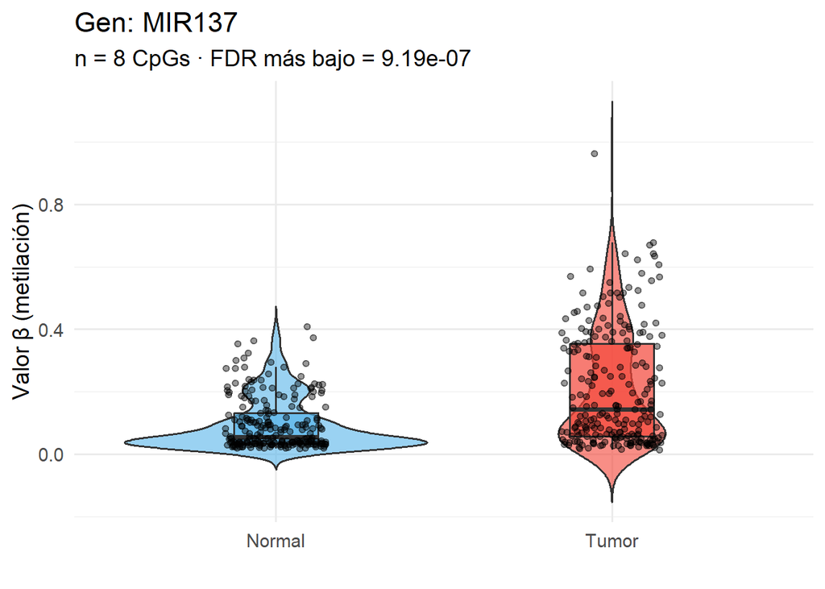

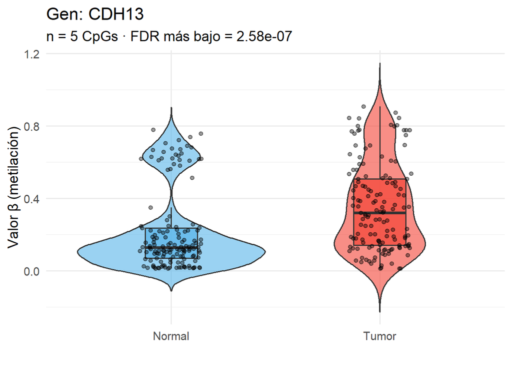

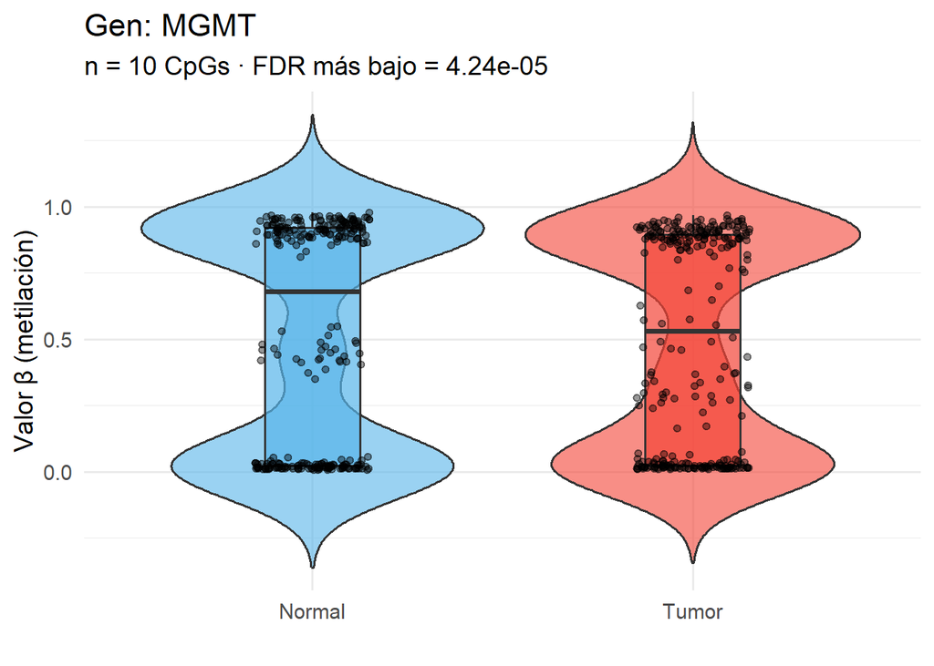

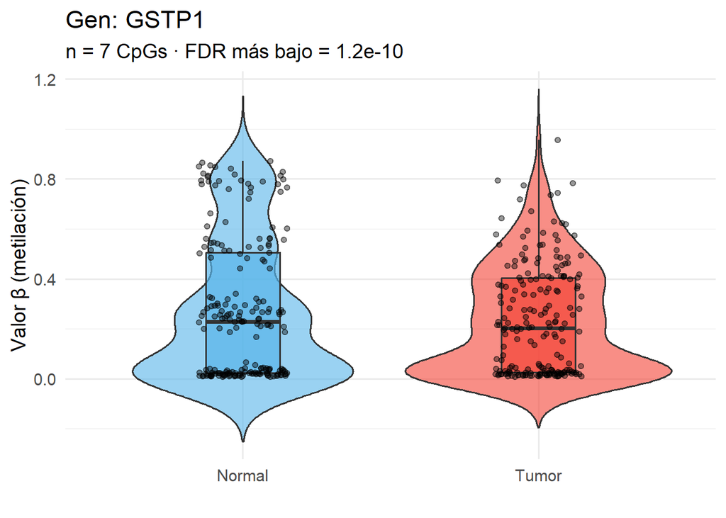

```r
for (g in genes_sig$gene) {
  dat <- luad_long %>% filter(gene == g)

  p <- ggplot(dat, aes(x = group, y = beta, fill = group)) +
    geom_violin(trim = FALSE, alpha = 0.6) +
    geom_boxplot(width = 0.25, outlier.alpha = 0, alpha = 0.7) +
    geom_jitter(width = 0.15, alpha = 0.4, size = 1.5) +
    scale_fill_manual(values = c("Normal" = "#56B4E9", "Tumor" = "#F44336")) +
    labs(title = paste("Gen:", g),
         subtitle = paste("n =", length(unique(dat$probe)), "CpGs · FDR más bajo =",
                          format(min(cpgs_sig$p_adj_gen[cpgs_sig$gene == g]), scientific = TRUE, digits = 3)),
         y = "Valor β (metilación)",
         x = "") +
    theme_minimal(base_size = 14) +
    theme(legend.position = "none")

  print(p)
}
```

## 10.9 Violin + boxplots por gen **conectando cada CG entre los tipos de tejido** (solo genes significativos)

**Código**

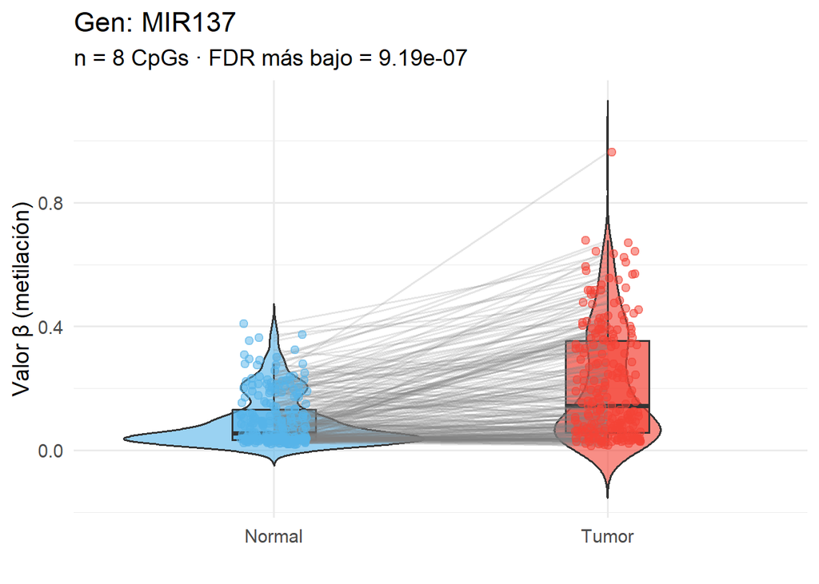

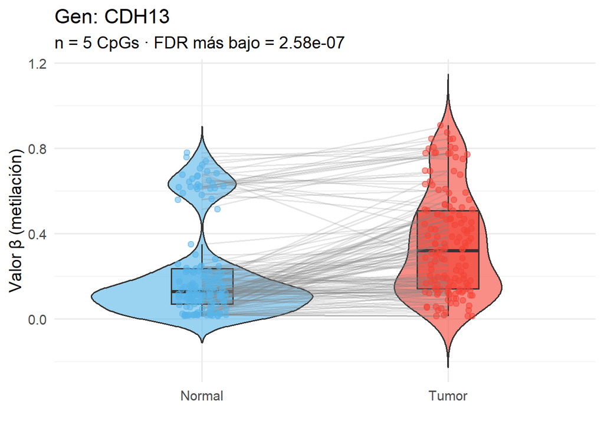

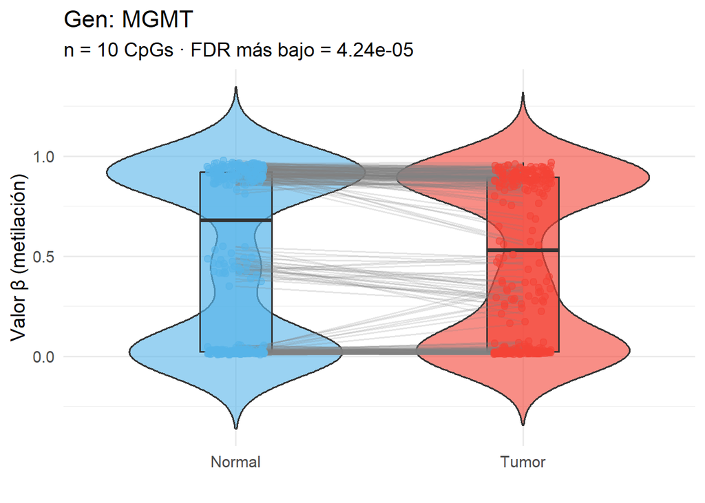

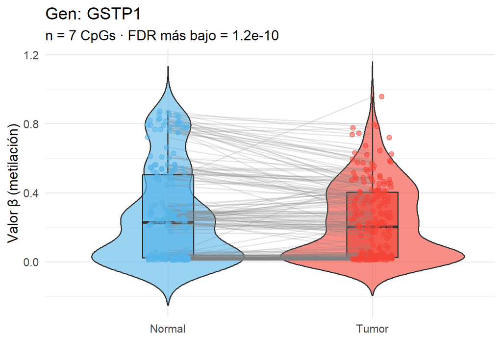

```r
for (g in genes_sig$gene) {
  dat <- luad_long %>% filter(gene == g)

  p <- ggplot(dat, aes(x = group, y = beta, fill = group)) +
    geom_violin(trim = FALSE, alpha = 0.6) +
    geom_boxplot(width = 0.25, outlier.alpha = 0, alpha = 0.7) +
    geom_line(aes(group = interaction(patient, probe)), alpha = 0.2, color = "gray50") +
    geom_point(aes(color = group), alpha = 0.5, size = 2,
               position = position_jitter(width = 0.1)) +
    scale_fill_manual(values = c("Normal" = "#56B4E9", "Tumor" = "#F44336")) +
    scale_color_manual(values = c("Normal" = "#56B4E9", "Tumor" = "#F44336")) +
    labs(title = paste("Gen:", g),
         subtitle = paste("n =", length(unique(dat$probe)), "CpGs · FDR más bajo =",
                          format(min(cpgs_sig$p_adj_gen[cpgs_sig$gene == g]), scientific = TRUE, digits = 3)),
         y = "Valor β (metilación)",
         x = "") +
    theme_minimal(base_size = 14) +
    theme(legend.position = "none")

  print(p)
}
```

## Mensaje Final

¡Felicidades! Has completado el análisis de metilación del ADN del proyecto **TCGA-LUAD**.

En este ejercicio aprendiste a:

#### **1. Gestionar datos de metilación 450K del TCGA**

- Descargar y organizar datos del proyecto TCGA-LUAD.
- Seleccionar únicamente **muestras pareadas** (tejido tumoral y normal del mismo paciente).
- Filtrar sondas CpG ubicadas en **regiones promotoras** de genes candidatos.

#### **2. Comparar metilación entre tejido tumoral y normal**

Aplicaste análisis estadísticos tanto a nivel de sonda como de gen: - **Wilcoxon probe-wise:** comparación por CpG individual  
- **Wilcoxon gene-wise:** agregación de CpGs por gen para evaluar cambios globales  
- Corrección por múltiples comparaciones mediante **FDR**

#### **3. Identificar cambios epigenéticos relevantes**

- CpGs y genes diferencialmente metilados
- Cálculo de **Δβ (delta beta)** entre grupos
- Ajuste de valores p a nivel de gen y globalmente

#### **4. Visualizar resultados de forma informativa**

- Heatmaps de CpGs significativos con anotaciones de genes
- Heatmaps a nivel de gen (promedios o medianas de sondas)
- Anotaciones de tipo de muestra (Normal vs Tumoral) mediante códigos de color

#### **5. Exportar resultados**

- Generación de un archivo Excel con resultados organizados en **múltiples hojas** para facilitar análisis posteriores.

Este flujo de trabajo te proporciona una base para comenzar a experimentar con datos de repositorios públicos y para automatizar el análisis estadístico, de modo que puedas plantear proyectos con hipótesis preliminares basadas en datos (*data-driven*).